# slide_rule

## slide_rule

#### Question

1. Before cheap hand-held calculators, students learned to use [slide rules](https://en.wikipedia.org/wiki/Slide_rule) to multiply numbers. As a simple example, we can see the slide rule below can be used to show that 2.00 times 5.00 equals 10.00.

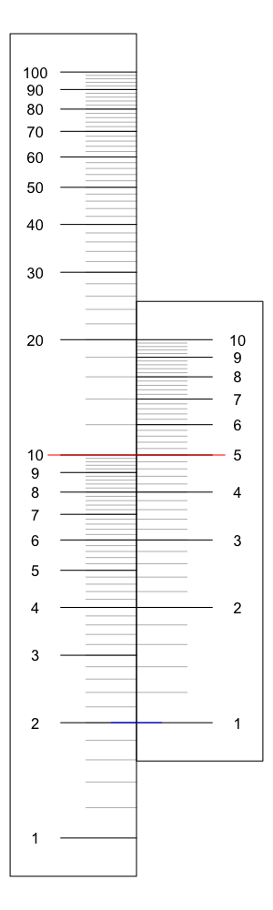

   Below is another slide rule. Based on the second slide’s position, and the red cursor’s position, the slide rule indicates another product of two factors.

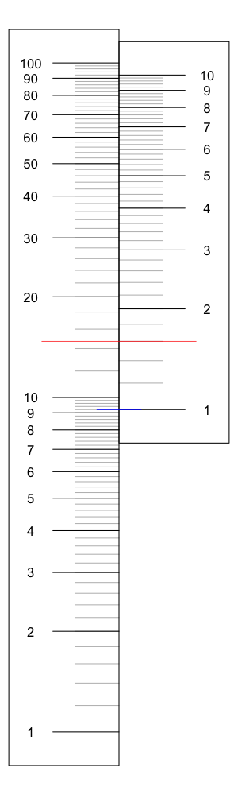

   The current position of the slide rule (and the red cursor) indicates a specific product. If that product is $a \cdot b = p$, find those three quantities.
   - $a =$
   - $b =$
   - $p \approx$

#### Question

2. Before cheap hand-held calculators, students learned to use [slide rules](https://en.wikipedia.org/wiki/Slide_rule) to multiply numbers. As a simple example, we can see the slide rule below can be used to show that 7.00 times 3.00 equals 21.00.

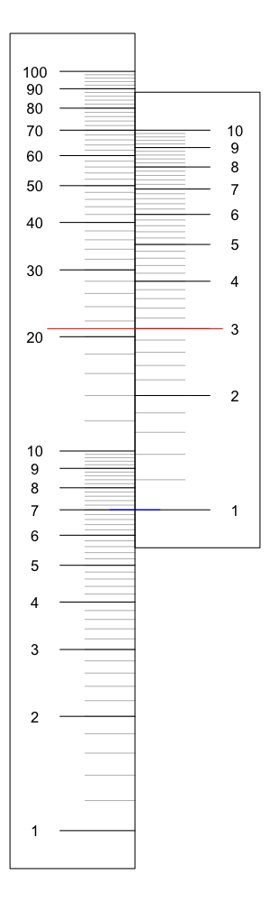

   Below is another slide rule. Based on the second slide’s position, and the red cursor’s position, the slide rule indicates another product of two factors.

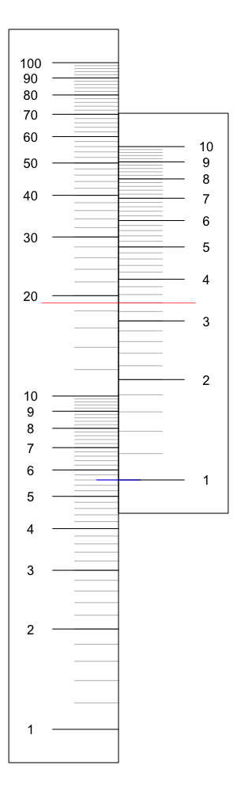

   The current position of the slide rule (and the red cursor) indicates a specific product. If that product is $a \cdot b = p$, find those three quantities.
   - $a =$
   - $b =$
   - $p \approx$

#### Question

3. Before cheap hand-held calculators, students learned to use [slide rules](https://en.wikipedia.org/wiki/Slide_rule) to multiply numbers. As a simple example, we can see the slide rule below can be used to show that 2.00 times 9.00 equals 18.00.

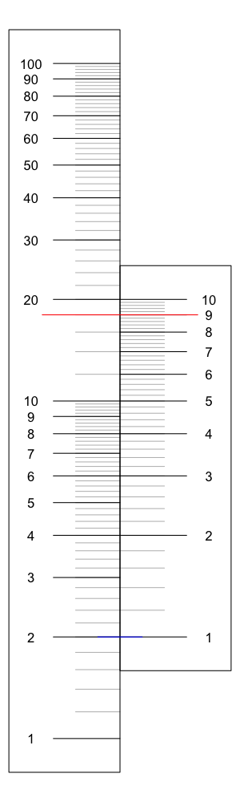

   Below is another slide rule. Based on the second slide’s position, and the red cursor’s position, the slide rule indicates another product of two factors.

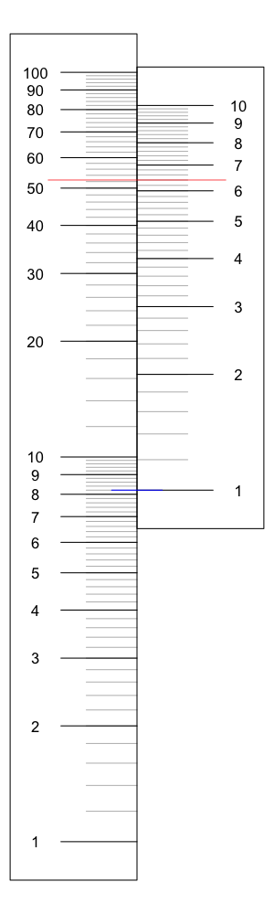

   The current position of the slide rule (and the red cursor) indicates a specific product. If that product is $a \cdot b = p$, find those three quantities.
   - $a =$
   - $b =$
   - $p \approx$

#### Question

4. Before cheap hand-held calculators, students learned to use [slide rules](https://en.wikipedia.org/wiki/Slide_rule) to multiply numbers. As a simple example, we can see the slide rule below can be used to show that 4.00 times 7.00 equals 28.00.

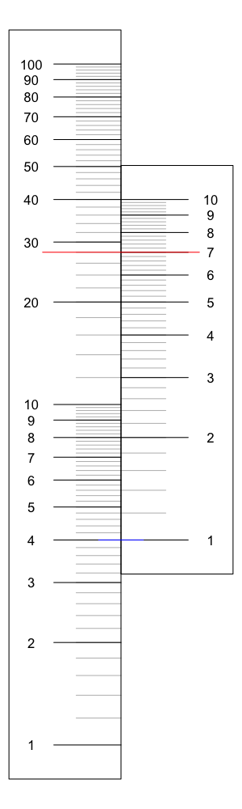

   Below is another slide rule. Based on the second slide’s position, and the red cursor’s position, the slide rule indicates another product of two factors.

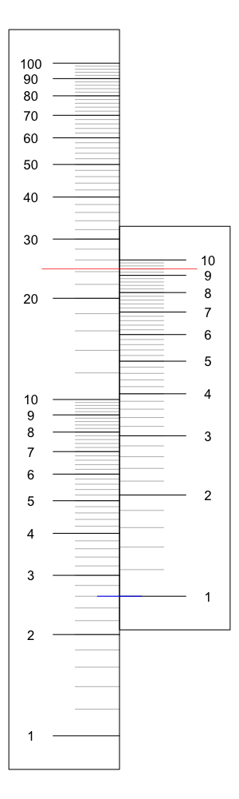

   The current position of the slide rule (and the red cursor) indicates a specific product. If that product is $a \cdot b = p$, find those three quantities.
   - $a =$
   - $b =$
   - $p \approx$

#### Question

5. Before cheap hand-held calculators, students learned to use [slide rules](https://en.wikipedia.org/wiki/Slide_rule) to multiply numbers. As a simple example, we can see the slide rule below can be used to show that 3.00 times 8.00 equals 24.00.

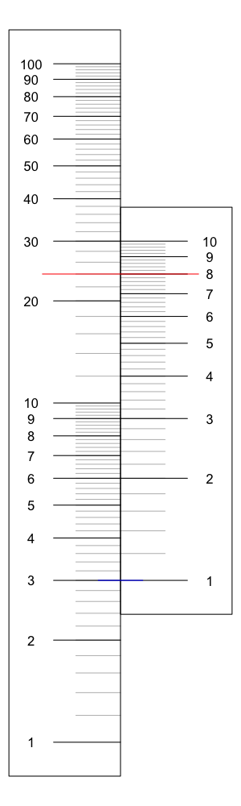

   Below is another slide rule. Based on the second slide’s position, and the red cursor’s position, the slide rule indicates another product of two factors.

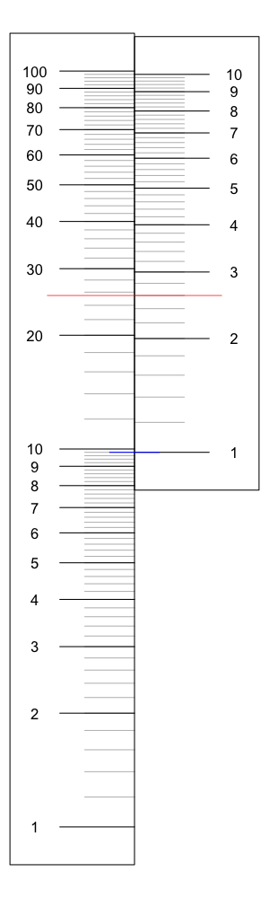

   The current position of the slide rule (and the red cursor) indicates a specific product. If that product is $a \cdot b = p$, find those three quantities.
   - $a =$
   - $b =$
   - $p \approx$

#### Question

6. Before cheap hand-held calculators, students learned to use [slide rules](https://en.wikipedia.org/wiki/Slide_rule) to multiply numbers. As a simple example, we can see the slide rule below can be used to show that 3.00 times 7.00 equals 21.00.

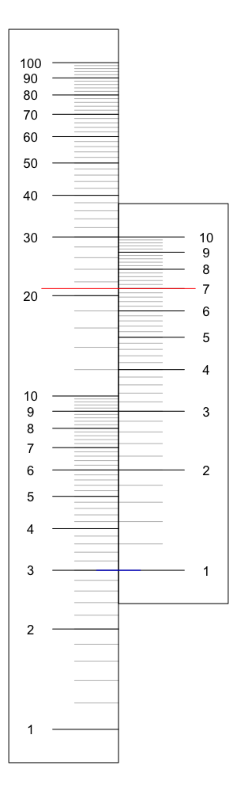

   Below is another slide rule. Based on the second slide’s position, and the red cursor’s position, the slide rule indicates another product of two factors.

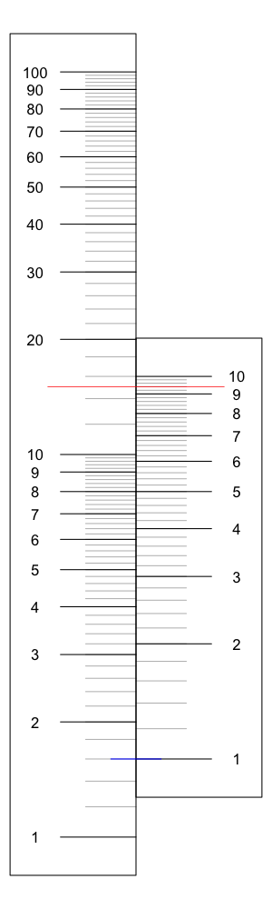

   The current position of the slide rule (and the red cursor) indicates a specific product. If that product is $a \cdot b = p$, find those three quantities.
   - $a =$
   - $b =$
   - $p \approx$

#### Question

7. Before cheap hand-held calculators, students learned to use [slide rules](https://en.wikipedia.org/wiki/Slide_rule) to multiply numbers. As a simple example, we can see the slide rule below can be used to show that 9.00 times 8.00 equals 72.00.

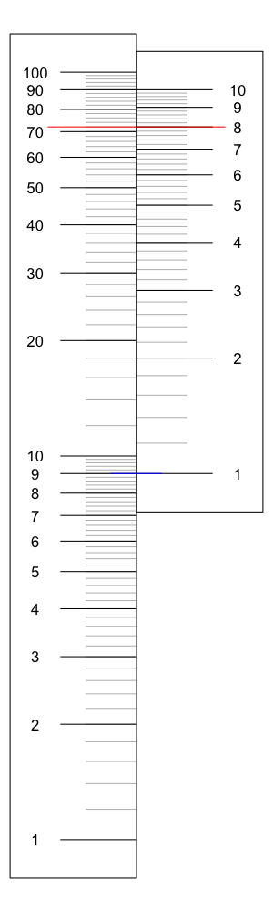

   Below is another slide rule. Based on the second slide’s position, and the red cursor’s position, the slide rule indicates another product of two factors.

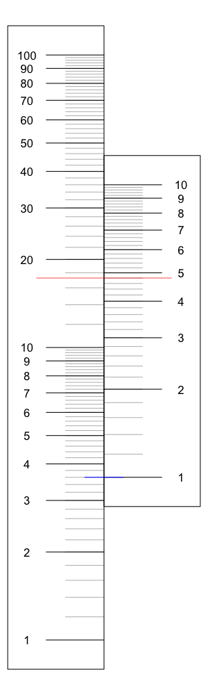

   The current position of the slide rule (and the red cursor) indicates a specific product. If that product is $a \cdot b = p$, find those three quantities.
   - $a =$
   - $b =$
   - $p \approx$

#### Question

8. Before cheap hand-held calculators, students learned to use [slide rules](https://en.wikipedia.org/wiki/Slide_rule) to multiply numbers. As a simple example, we can see the slide rule below can be used to show that 9.00 times 2.00 equals 18.00.

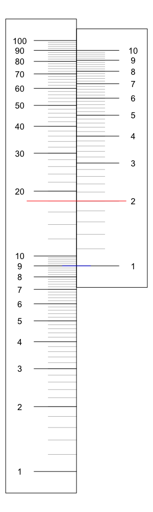

   Below is another slide rule. Based on the second slide’s position, and the red cursor’s position, the slide rule indicates another product of two factors.

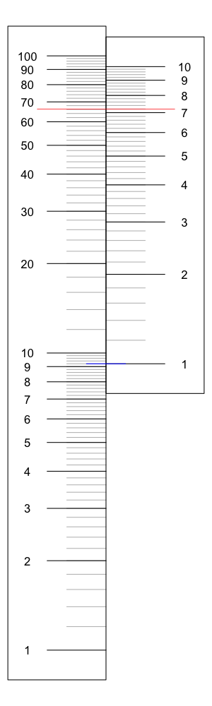

   The current position of the slide rule (and the red cursor) indicates a specific product. If that product is $a \cdot b = p$, find those three quantities.
   - $a =$
   - $b =$
   - $p \approx$